# AV_Sentiment_Analysis_BERT

**Twitter Sentiment Analysis**

The objective of this task is to detect hate speech in tweets.

We are given a training sample of tweets and labels, where label '1' denotes negative tweet (with hate speech) and label '0' denotes positive tweet (with out hate speech).

Our objective is to predict the labels on the test dataset.

**Data** Our overall collection of tweets was split in the ratio of 65:35 into training and testing data. Out of the testing data, 30% is public and the rest is private.

**Evaluation Metric:** The metric used for evaluating the performance of classification model would be F1-Score.

Precision = TP/TP+FP

Recall = TP/TP+FN

F1 Score = 2(Recall Precision) / (Recall + Precision)

**Loading train and test data**

```python
import os
os.chdir(r"/content/drive/My Drive/Data")
import pandas as pd
train=pd.read_csv("train_E6oV3lV.csv")
test=pd.read_csv("test_tweets_anuFYb8.csv")
submission=pd.read_csv("sample_submission_gfvA5FD.csv")
```

**Understanding data**

```python
print("train data has {} rows and {} columns".format(train.shape[0],train.shape[1]))
print("test data has {} rows and {} columns".format(test.shape[0],test.shape[1]))
```

```
train data has 31962 rows and 3 columns
test data has 17197 rows and 2 columns
```

```python
print("\ntrain datatypes-->\n")
print(train.dtypes)
print("\ntest datatypes-->\n")
print(test.dtypes)
```

```
train datatypes-->

id        int64
label     int64
tweet    object
dtype: object

test datatypes-->

id        int64
tweet    object
dtype: object
```

```python
import numpy as np
np.unique(train['label'], return_counts=True)
```

```
(array([0, 1]), array([29720,  2242]))
```

```python
train.head(20)
```

|  | id | label | tweet |
| --- | --- | --- | --- |
| 0 | 1 | 0 | @user when a father is dysfunctional and is s... |
| 1 | 2 | 0 | @user @user thanks for #lyft credit i can't us... |
| 2 | 3 | 0 | bihday your majesty |
| 3 | 4 | 0 | #model i love u take with u all the time in ... |
| 4 | 5 | 0 | factsguide: society now #motivation |
| 5 | 6 | 0 | [2/2] huge fan fare and big talking before the... |
| 6 | 7 | 0 | @user camping tomorrow @user @user @user @use... |
| 7 | 8 | 0 | the next school year is the year for exams.ð... |
| 8 | 9 | 0 | we won!!! love the land!!! #allin #cavs #champ... |
| 9 | 10 | 0 | @user @user welcome here ! i'm it's so #gr... |
| 10 | 11 | 0 | â #ireland consumer price index (mom) climb... |
| 11 | 12 | 0 | we are so selfish. #orlando #standwithorlando ... |
| 12 | 13 | 0 | i get to see my daddy today!! #80days #getti... |
| 13 | 14 | 1 | @user #cnn calls #michigan middle school 'buil... |
| 14 | 15 | 1 | no comment! in #australia #opkillingbay #se... |
| 15 | 16 | 0 | ouch...junior is angryð#got7 #junior #yugyo... |
| 16 | 17 | 0 | i am thankful for having a paner. #thankful #p... |
| 17 | 18 | 1 | retweet if you agree! |
| 18 | 19 | 0 | its #friday! ð smiles all around via ig use... |
| 19 | 20 | 0 | as we all know, essential oils are not made of... |

The data has @User mentions and #tag mentions, preprocessing step involves removing these tags.

**Data cleaning**

```python
import re
def remove_handles(text,pattern):
    handles=re.findall(pattern,text)
    for handle in handles:
        text=re.sub(handle,'',text)
    return text

# Remove twitter handles
train['clean_tweet']=train.tweet.apply(lambda tweet: remove_handles(str(tweet),"@[\w]*"))
```

```python
train.head(20)
```

|  | id | label | tweet | clean_tweet |
| --- | --- | --- | --- | --- |
| 0 | 1 | 0 | @user when a father is dysfunctional and is s... | when a father is dysfunctional and is so sel... |
| 1 | 2 | 0 | @user @user thanks for #lyft credit i can't us... | thanks for #lyft credit i can't use cause th... |
| 2 | 3 | 0 | bihday your majesty | bihday your majesty |
| 3 | 4 | 0 | #model i love u take with u all the time in ... | #model i love u take with u all the time in ... |
| 4 | 5 | 0 | factsguide: society now #motivation | factsguide: society now #motivation |
| 5 | 6 | 0 | [2/2] huge fan fare and big talking before the... | [2/2] huge fan fare and big talking before the... |
| 6 | 7 | 0 | @user camping tomorrow @user @user @user @use... | camping tomorrow dannyâ¦ |
| 7 | 8 | 0 | the next school year is the year for exams.ð... | the next school year is the year for exams.ð... |
| 8 | 9 | 0 | we won!!! love the land!!! #allin #cavs #champ... | we won!!! love the land!!! #allin #cavs #champ... |
| 9 | 10 | 0 | @user @user welcome here ! i'm it's so #gr... | welcome here ! i'm it's so #gr8 ! |
| 10 | 11 | 0 | â #ireland consumer price index (mom) climb... | â #ireland consumer price index (mom) climb... |
| 11 | 12 | 0 | we are so selfish. #orlando #standwithorlando ... | we are so selfish. #orlando #standwithorlando ... |
| 12 | 13 | 0 | i get to see my daddy today!! #80days #getti... | i get to see my daddy today!! #80days #getti... |
| 13 | 14 | 1 | @user #cnn calls #michigan middle school 'buil... | #cnn calls #michigan middle school 'build the... |
| 14 | 15 | 1 | no comment! in #australia #opkillingbay #se... | no comment! in #australia #opkillingbay #se... |
| 15 | 16 | 0 | ouch...junior is angryð#got7 #junior #yugyo... | ouch...junior is angryð#got7 #junior #yugyo... |
| 16 | 17 | 0 | i am thankful for having a paner. #thankful #p... | i am thankful for having a paner. #thankful #p... |
| 17 | 18 | 1 | retweet if you agree! | retweet if you agree! |
| 18 | 19 | 0 | its #friday! ð smiles all around via ig use... | its #friday! ð smiles all around via ig use... |
| 19 | 20 | 0 | as we all know, essential oils are not made of... | as we all know, essential oils are not made of... |

```python
def remove_specialchars(text,pattern):
    text=re.sub(pattern,' ',text)
    return text

# Remove special characters,numbers and punctuations except " # ", " ' ", ",", "." and "!"
train['clean_tweet']=train.clean_tweet.apply(lambda tweet: remove_specialchars(str(tweet),"[^a-zA-Z'#,.!]"))
```

```python
train.head(20)
```

|  | id | label | tweet | clean_tweet |
| --- | --- | --- | --- | --- |
| 0 | 1 | 0 | @user when a father is dysfunctional and is s... | when a father is dysfunctional and is so sel... |
| 1 | 2 | 0 | @user @user thanks for #lyft credit i can't us... | thanks for #lyft credit i can't use cause th... |
| 2 | 3 | 0 | bihday your majesty | bihday your majesty |
| 3 | 4 | 0 | #model i love u take with u all the time in ... | #model i love u take with u all the time in ... |
| 4 | 5 | 0 | factsguide: society now #motivation | factsguide society now #motivation |
| 5 | 6 | 0 | [2/2] huge fan fare and big talking before the... | huge fan fare and big talking before the... |
| 6 | 7 | 0 | @user camping tomorrow @user @user @user @use... | camping tomorrow danny |
| 7 | 8 | 0 | the next school year is the year for exams.ð... | the next school year is the year for exams. ... |
| 8 | 9 | 0 | we won!!! love the land!!! #allin #cavs #champ... | we won!!! love the land!!! #allin #cavs #champ... |
| 9 | 10 | 0 | @user @user welcome here ! i'm it's so #gr... | welcome here ! i'm it's so #gr ! |
| 10 | 11 | 0 | â #ireland consumer price index (mom) climb... | #ireland consumer price index mom climb... |
| 11 | 12 | 0 | we are so selfish. #orlando #standwithorlando ... | we are so selfish. #orlando #standwithorlando ... |
| 12 | 13 | 0 | i get to see my daddy today!! #80days #getti... | i get to see my daddy today!! # days #getti... |
| 13 | 14 | 1 | @user #cnn calls #michigan middle school 'buil... | #cnn calls #michigan middle school 'build the... |
| 14 | 15 | 1 | no comment! in #australia #opkillingbay #se... | no comment! in #australia #opkillingbay #se... |
| 15 | 16 | 0 | ouch...junior is angryð#got7 #junior #yugyo... | ouch...junior is angry #got #junior #yugyo... |
| 16 | 17 | 0 | i am thankful for having a paner. #thankful #p... | i am thankful for having a paner. #thankful #p... |
| 17 | 18 | 1 | retweet if you agree! | retweet if you agree! |
| 18 | 19 | 0 | its #friday! ð smiles all around via ig use... | its #friday! smiles all around via ig use... |
| 19 | 20 | 0 | as we all know, essential oils are not made of... | as we all know, essential oils are not made of... |

```python
# Replace short cuts with actual words
shortcuts = {'u': 'you', 'y': 'why', 'r': 'are', 'doin': 'doing', 'hw': 'how', 'k': 'okay', 'm': 'am', 'b4': 'before',
            'idc': "i do not care", 'ty': 'thankyou', 'wlcm': 'welcome', 'bc': 'because', '<3': 'love', 'xoxo': 'love',
            'ttyl': 'talk to you later', 'gr8': 'great', 'bday': 'birthday', 'awsm': 'awesome', 'gud': 'good', 'h8': 'hate',
            'lv': 'love', 'dm': 'direct message', 'rt': 'retweet', 'wtf': 'hate', 'idgaf': 'hate',
             'irl': 'in real life', 'yolo': 'you only live once', 'ur': 'your'}

def replace_shortcuts(text):
    for i,token in enumerate(text):
        if token in shortcuts.keys():
            token=shortcuts[token]
            text[i]=token
    return text

train.clean_tweet=train.clean_tweet.apply(lambda tweet: replace_shortcuts(tweet.split()))
```

```python
train.head(20)
```

|  | id | label | tweet | clean_tweet |
| --- | --- | --- | --- | --- |
| 0 | 1 | 0 | @user when a father is dysfunctional and is s... | [when, a, father, is, dysfunctional, and, is, ... |
| 1 | 2 | 0 | @user @user thanks for #lyft credit i can't us... | [thanks, for, #lyft, credit, i, can't, use, ca... |
| 2 | 3 | 0 | bihday your majesty | [bihday, your, majesty] |
| 3 | 4 | 0 | #model i love u take with u all the time in ... | [#model, i, love, you, take, with, you, all, t... |
| 4 | 5 | 0 | factsguide: society now #motivation | [factsguide, society, now, #motivation] |
| 5 | 6 | 0 | [2/2] huge fan fare and big talking before the... | [huge, fan, fare, and, big, talking, before, t... |
| 6 | 7 | 0 | @user camping tomorrow @user @user @user @use... | [camping, tomorrow, danny] |
| 7 | 8 | 0 | the next school year is the year for exams.ð... | [the, next, school, year, is, the, year, for, ... |
| 8 | 9 | 0 | we won!!! love the land!!! #allin #cavs #champ... | [we, won!!!, love, the, land!!!, #allin, #cavs... |
| 9 | 10 | 0 | @user @user welcome here ! i'm it's so #gr... | [welcome, here, !, i'm, it's, so, #gr, !] |
| 10 | 11 | 0 | â #ireland consumer price index (mom) climb... | [#ireland, consumer, price, index, mom, climbe... |
| 11 | 12 | 0 | we are so selfish. #orlando #standwithorlando ... | [we, are, so, selfish., #orlando, #standwithor... |
| 12 | 13 | 0 | i get to see my daddy today!! #80days #getti... | [i, get, to, see, my, daddy, today!!, #, days,... |
| 13 | 14 | 1 | @user #cnn calls #michigan middle school 'buil... | [#cnn, calls, #michigan, middle, school, 'buil... |
| 14 | 15 | 1 | no comment! in #australia #opkillingbay #se... | [no, comment!, in, #australia, #opkillingbay, ... |
| 15 | 16 | 0 | ouch...junior is angryð#got7 #junior #yugyo... | [ouch...junior, is, angry, #got, #junior, #yug... |
| 16 | 17 | 0 | i am thankful for having a paner. #thankful #p... | [i, am, thankful, for, having, a, paner., #tha... |
| 17 | 18 | 1 | retweet if you agree! | [retweet, if, you, agree!] |
| 18 | 19 | 0 | its #friday! ð smiles all around via ig use... | [its, #friday!, smiles, all, around, via, ig, ... |
| 19 | 20 | 0 | as we all know, essential oils are not made of... | [as, we, all, know,, essential, oils, are, not... |

```python
def hashtag_extract(text):
    tweet=(" ").join(text)
    hashtags=re.findall(r"#(\w+)",tweet)
    return hashtags

# Extract hashtags to a new column
train['hashtags']=train.clean_tweet.apply(lambda tweet: hashtag_extract(tweet))
```

```python
def remove_hash(text,pattern):
    for i,token in enumerate(text):
        word=re.sub(pattern,'',token)
        text[i]=word
    return text

# Remove # from tweet
train['clean_tweet']=train.clean_tweet.apply(lambda tweet: remove_hash(tweet,'#'))
```

```python
train.head(20)
```

|  | id | label | tweet | clean_tweet | hashtags |
| --- | --- | --- | --- | --- | --- |
| 0 | 1 | 0 | @user when a father is dysfunctional and is s... | [when, a, father, is, dysfunctional, and, is, ... | [run] |
| 1 | 2 | 0 | @user @user thanks for #lyft credit i can't us... | [thanks, for, lyft, credit, i, can't, use, cau... | [lyft, disapointed, getthanked] |
| 2 | 3 | 0 | bihday your majesty | [bihday, your, majesty] | [] |
| 3 | 4 | 0 | #model i love u take with u all the time in ... | [model, i, love, you, take, with, you, all, th... | [model] |
| 4 | 5 | 0 | factsguide: society now #motivation | [factsguide, society, now, motivation] | [motivation] |
| 5 | 6 | 0 | [2/2] huge fan fare and big talking before the... | [huge, fan, fare, and, big, talking, before, t... | [allshowandnogo] |
| 6 | 7 | 0 | @user camping tomorrow @user @user @user @use... | [camping, tomorrow, danny] | [] |
| 7 | 8 | 0 | the next school year is the year for exams.ð... | [the, next, school, year, is, the, year, for, ... | [school, exams, hate, imagine, actorslife, rev... |
| 8 | 9 | 0 | we won!!! love the land!!! #allin #cavs #champ... | [we, won!!!, love, the, land!!!, allin, cavs, ... | [allin, cavs, champions, cleveland, clevelandc... |
| 9 | 10 | 0 | @user @user welcome here ! i'm it's so #gr... | [welcome, here, !, i'm, it's, so, gr, !] | [gr] |
| 10 | 11 | 0 | â #ireland consumer price index (mom) climb... | [ireland, consumer, price, index, mom, climbed... | [ireland, blog, silver, gold, forex] |
| 11 | 12 | 0 | we are so selfish. #orlando #standwithorlando ... | [we, are, so, selfish., orlando, standwithorla... | [orlando, standwithorlando, pulseshooting, orl... |
| 12 | 13 | 0 | i get to see my daddy today!! #80days #getti... | [i, get, to, see, my, daddy, today!!, , days, ... | [gettingfed] |
| 13 | 14 | 1 | @user #cnn calls #michigan middle school 'buil... | [cnn, calls, michigan, middle, school, 'build,... | [cnn, michigan, tcot] |
| 14 | 15 | 1 | no comment! in #australia #opkillingbay #se... | [no, comment!, in, australia, opkillingbay, se... | [australia, opkillingbay, seashepherd, helpcov... |
| 15 | 16 | 0 | ouch...junior is angryð#got7 #junior #yugyo... | [ouch...junior, is, angry, got, junior, yugyoe... | [got, junior, yugyoem, omg] |
| 16 | 17 | 0 | i am thankful for having a paner. #thankful #p... | [i, am, thankful, for, having, a, paner., than... | [thankful, positive] |
| 17 | 18 | 1 | retweet if you agree! | [retweet, if, you, agree!] | [] |
| 18 | 19 | 0 | its #friday! ð smiles all around via ig use... | [its, friday!, smiles, all, around, via, ig, u... | [friday, cookies] |
| 19 | 20 | 0 | as we all know, essential oils are not made of... | [as, we, all, know,, essential, oils, are, not... | [] |

Converting unstructured text to structured numeric format

```python
def join_tokens(text):
    return (' '.join(text))

train.clean_tweet=train.clean_tweet.apply(lambda tweet: join_tokens(tweet))
```

```python
train.head()
```

|  | id | label | tweet | clean_tweet | hashtags |
| --- | --- | --- | --- | --- | --- |
| 0 | 1 | 0 | @user when a father is dysfunctional and is s... | when a father is dysfunctional and is so selfi... | [run] |
| 1 | 2 | 0 | @user @user thanks for #lyft credit i can't us... | thanks for lyft credit i can't use cause they ... | [lyft, disapointed, getthanked] |
| 2 | 3 | 0 | bihday your majesty | bihday your majesty | [] |
| 3 | 4 | 0 | #model i love u take with u all the time in ... | model i love you take with you all the time in... | [model] |
| 4 | 5 | 0 | factsguide: society now #motivation | factsguide society now motivation | [motivation] |

**! ! ! ! ! ! ! ! ! ! ! BERT ! ! ! ! ! ! ! ! ! ! !**

**BERT Setup**

```python
!python -m pip install transformers
```

**Importing required libraries**

```python
import transformers
import torch

import copy
import numpy as np
import pandas as pd

import seaborn as sns
from pylab import rcParams
import matplotlib.pyplot as plt
from matplotlib import rc

%matplotlib inline
%config InlineBackend.figure_format='retina'
sns.set(style='whitegrid', palette='muted', font_scale=1.2)
HAPPY_COLORS_PALETTE = ["#01BEFE", "#FFDD00", "#FF7D00", "#FF006D", "#ADFF02", "#8F00FF"]
sns.set_palette(sns.color_palette(HAPPY_COLORS_PALETTE))
rcParams['figure.figsize'] = 8, 6

from sklearn.model_selection import train_test_split
from tqdm import tqdm

from torch import nn, optim
from torch.utils import data
from torch.utils.data import Dataset, DataLoader
from transformers import BertModel, BertTokenizer, AdamW, get_linear_schedule_with_warmup
import torch.nn.functional as F

RANDOM_SEED = 42
np.random.seed(RANDOM_SEED)
torch.manual_seed(RANDOM_SEED)
device = torch.device("cuda:0" if torch.cuda.is_available() else "cpu")
```

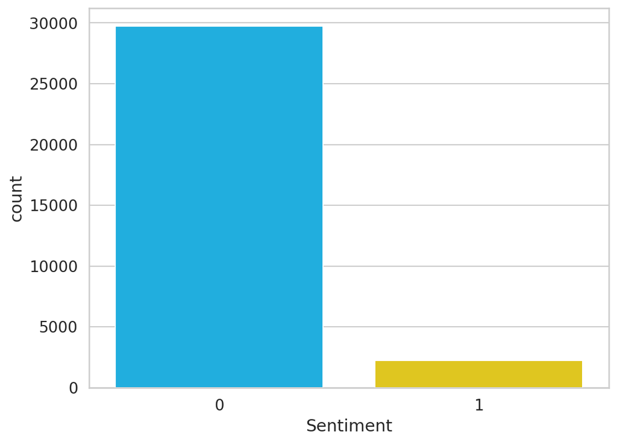

```python
sns.countplot(train.label)
plt.xlabel('Sentiment')
```

That's hugely imbalanced.

**Data Preprocessing**

```python
tokenizer = transformers.BertTokenizer.from_pretrained('bert-base-cased')
```

Choosing sequence length

```python
def tweet_max_length(tweets):
    token_lens=[]
    for tweet in tweets:
      tokens = tokenizer.encode(tweet,max_length=512, truncation = True)
      token_lens.append(len(tokens))
    return token_lens

token_lens=tweet_max_length(train.clean_tweet)
```

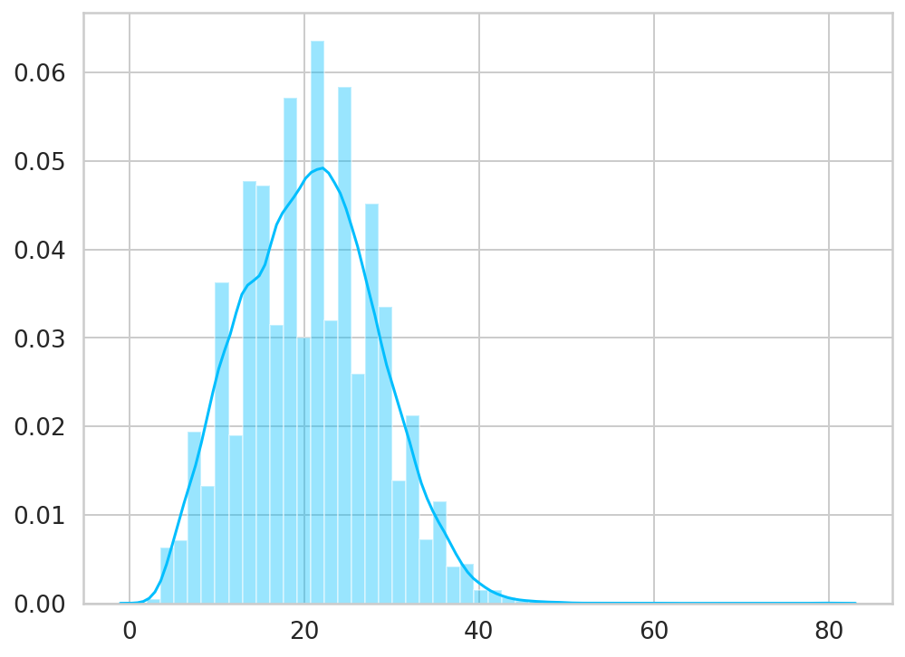

```python
sns.distplot(token_lens)
```

```python
print("max length",max(token_lens))
print("mean length",np.mean(token_lens))
```

```
max length 80
mean length 20.663850822852137
```

```python
train.columns
```

```
Index(['id', 'label', 'tweet', 'clean_tweet', 'hashtags'], dtype='object')
```

Based on the distribution 50 can be a good sequence length so it is set as max_length

```python
class TwitterTweetsDataset(data.Dataset):
# constructor
  def __init__(self, tweet, target, tokenizer, max_len):
    self.tweet = tweet
    self.target = target
    self.tokenizer = tokenizer
    self.max_len = max_len

# To get the number of tweets
  def __len__(self):
    return (len(self.tweet))

# To get the tweet of an item
  def __getitem__(self, item):
    tweet = str(self.tweet[item])
    target = self.target[item]

    encoding=tokenizer.encode_plus(
                                   tweet,
                                   max_length=self.max_len,
                                   add_special_tokens=True,
                                   pad_to_max_length=True,
                                   return_attention_mask=True,
                                   return_token_type_ids=False,
                                   return_tensors='pt',
                                   truncation=True
                                   )

    return {
              'tweet_text': tweet,
              'input_ids': encoding['input_ids'].flatten(),
              'attention_mask': encoding['attention_mask'].flatten(),
              'targets' : torch.tensor(target,dtype=torch.long)
            }
```

Train validation split

```python
df_train, df_val = train_test_split(train, test_size=0.2, random_state=RANDOM_SEED)
```

```python
df_train.shape, df_val.shape
```

```
((25569, 5), (6393, 5))
```

```python
MAX_LEN = 50
BATCH_SIZE = 32
EPOCHS = 10
```

```python
def create_data_loader(df, tokenizer, max_len, batch_size):

  # creating an instance of the TwitterTweetsDataset
  ds = TwitterTweetsDataset(
                            tweet=df.clean_tweet.to_numpy(),
                            target=df.label.to_numpy(),
                            tokenizer=tokenizer,
                            max_len=max_len
                            )

  return data.DataLoader(
                         ds,
                         batch_size=batch_size,
                         num_workers=4)
```

```python
train_data_loader = create_data_loader(df_train, tokenizer, MAX_LEN, BATCH_SIZE)
val_data_loader = create_data_loader(df_val, tokenizer, MAX_LEN, BATCH_SIZE)
```

```python
# We can iterate over the data loader and have a look at the inputs.
# Instead of this we rather have a simpler way by looking at a batch
data = next(iter(train_data_loader))
data.keys()
```

```
dict_keys(['tweet_text', 'input_ids', 'attention_mask', 'targets'])
```

```python
print(data['input_ids'].shape);print(data['attention_mask'].shape);print(data['targets'].shape);
```

```
torch.Size([32, 50])
torch.Size([32, 50])
torch.Size([32])
```

**Preparing test data**

```python
test=pd.read_csv("test_tweets_anuFYb8.csv")
test.head()
```

|  | id | tweet |
| --- | --- | --- |
| 0 | 31963 | #studiolife #aislife #requires #passion #dedic... |
| 1 | 31964 | @user #white #supremacists want everyone to s... |
| 2 | 31965 | safe ways to heal your #acne!! #altwaystohe... |
| 3 | 31966 | is the hp and the cursed child book up for res... |
| 4 | 31967 | 3rd #bihday to my amazing, hilarious #nephew... |

```python
# Remove twitter handles
test['clean_tweet']=test.tweet.apply(lambda tweet: remove_handles(str(tweet),"@[\w]*"))
```

```python
test.head()
```

|  | id | tweet | clean_tweet |
| --- | --- | --- | --- |
| 0 | 31963 | #studiolife #aislife #requires #passion #dedic... | #studiolife #aislife #requires #passion #dedic... |
| 1 | 31964 | @user #white #supremacists want everyone to s... | #white #supremacists want everyone to see th... |
| 2 | 31965 | safe ways to heal your #acne!! #altwaystohe... | safe ways to heal your #acne!! #altwaystohe... |
| 3 | 31966 | is the hp and the cursed child book up for res... | is the hp and the cursed child book up for res... |
| 4 | 31967 | 3rd #bihday to my amazing, hilarious #nephew... | 3rd #bihday to my amazing, hilarious #nephew... |

```python
# Remove special characters,numbers and punctuations except " # "," ' "," , "," . " and " ! "
test['clean_tweet']=test.clean_tweet.apply(lambda tweet: remove_specialchars(str(tweet),"[^a-zA-Z'#,.!]"))
```

```python
test.head()
```

|  | id | tweet | clean_tweet |
| --- | --- | --- | --- |
| 0 | 31963 | #studiolife #aislife #requires #passion #dedic... | #studiolife #aislife #requires #passion #dedic... |
| 1 | 31964 | @user #white #supremacists want everyone to s... | #white #supremacists want everyone to see th... |
| 2 | 31965 | safe ways to heal your #acne!! #altwaystohe... | safe ways to heal your #acne!! #altwaystohe... |
| 3 | 31966 | is the hp and the cursed child book up for res... | is the hp and the cursed child book up for res... |
| 4 | 31967 | 3rd #bihday to my amazing, hilarious #nephew... | rd #bihday to my amazing, hilarious #nephew... |

```python
# Replace short cuts with actual words
test.clean_tweet=test.clean_tweet.apply(lambda tweet: replace_shortcuts(tweet.split()))
```

```python
test.head()
```

|  | id | tweet | clean_tweet |
| --- | --- | --- | --- |
| 0 | 31963 | #studiolife #aislife #requires #passion #dedic... | [#studiolife, #aislife, #requires, #passion, #... |
| 1 | 31964 | @user #white #supremacists want everyone to s... | [#white, #supremacists, want, everyone, to, se... |
| 2 | 31965 | safe ways to heal your #acne!! #altwaystohe... | [safe, ways, to, heal, your, #acne!!, #altways... |
| 3 | 31966 | is the hp and the cursed child book up for res... | [is, the, hp, and, the, cursed, child, book, u... |
| 4 | 31967 | 3rd #bihday to my amazing, hilarious #nephew... | [rd, #bihday, to, my, amazing,, hilarious, #ne... |

```python
# Extract hashtags to a new column
test['hashtags']=test.clean_tweet.apply(lambda tweet: hashtag_extract(tweet))
```

```python
# Remove # from tweet
test['clean_tweet']=test.clean_tweet.apply(lambda tweet: remove_hash(tweet,'#'))
```

```python
test.head()
```

|  | id | tweet | clean_tweet | hashtags |
| --- | --- | --- | --- | --- |
| 0 | 31963 | #studiolife #aislife #requires #passion #dedic... | [studiolife, aislife, requires, passion, dedic... | [studiolife, aislife, requires, passion, dedic... |
| 1 | 31964 | @user #white #supremacists want everyone to s... | [white, supremacists, want, everyone, to, see,... | [white, supremacists, birds, movie] |
| 2 | 31965 | safe ways to heal your #acne!! #altwaystohe... | [safe, ways, to, heal, your, acne!!, altwaysto... | [acne, altwaystoheal, healthy, healing] |
| 3 | 31966 | is the hp and the cursed child book up for res... | [is, the, hp, and, the, cursed, child, book, u... | [harrypotter, pottermore, favorite] |
| 4 | 31967 | 3rd #bihday to my amazing, hilarious #nephew... | [rd, bihday, to, my, amazing,, hilarious, neph... | [bihday, nephew] |

```python
test.clean_tweet=test.clean_tweet.apply(lambda tweet: join_tokens(tweet))
```

```python
test.head()
```

|  | id | tweet | clean_tweet | hashtags |
| --- | --- | --- | --- | --- |
| 0 | 31963 | #studiolife #aislife #requires #passion #dedic... | studiolife aislife requires passion dedication... | [studiolife, aislife, requires, passion, dedic... |
| 1 | 31964 | @user #white #supremacists want everyone to s... | white supremacists want everyone to see the ne... | [white, supremacists, birds, movie] |
| 2 | 31965 | safe ways to heal your #acne!! #altwaystohe... | safe ways to heal your acne!! altwaystoheal he... | [acne, altwaystoheal, healthy, healing] |
| 3 | 31966 | is the hp and the cursed child book up for res... | is the hp and the cursed child book up for res... | [harrypotter, pottermore, favorite] |
| 4 | 31967 | 3rd #bihday to my amazing, hilarious #nephew... | rd bihday to my amazing, hilarious nephew eli ... | [bihday, nephew] |

```python
# Adding column for target
test['label']=0
```

```python
test.info()
```

```
<class 'pandas.core.frame.DataFrame'>
RangeIndex: 17197 entries, 0 to 17196
Data columns (total 5 columns):
 #   Column       Non-Null Count  Dtype
---  ------       --------------  -----
 0   id           17197 non-null  int64
 1   tweet        17197 non-null  object
 2   clean_tweet  17197 non-null  object
 3   hashtags     17197 non-null  object
 4   label        17197 non-null  int64
dtypes: int64(2), object(3)
memory usage: 671.9+ KB
```

**BERT data processing**

```python
test_data_loader = create_data_loader(test, tokenizer, MAX_LEN, BATCH_SIZE)
```

```python
# We can iterate over the data loader and have a look at the inputs.
# Instead of this we rather have a simpler way by looking at a batch
data = next(iter(train_data_loader))
data.keys()
```

```
dict_keys(['tweet_text', 'input_ids', 'attention_mask', 'targets'])
```

```python
print(data['input_ids'].shape);print(data['attention_mask'].shape);print(data['targets'].shape);
```

```
torch.Size([32, 50])
torch.Size([32, 50])
torch.Size([32])
```

Create a classifier that uses the pre-trained BERT model to create features (BERT contextual embeddings).

```python
class SentimentClassifier(nn.Module):

  def __init__(self, n_classes):
    super(SentimentClassifier, self).__init__()
    self.bert = BertModel.from_pretrained('bert-base-cased')
    self.drop = nn.Dropout(p=0.3)
    self.out = nn.Linear(self.bert.config.hidden_size, n_classes)

  def forward(self, input_ids, attention_mask):
    _, pooled_output = self.bert(
      input_ids=input_ids,
      attention_mask=attention_mask
    )

    output = self.drop(pooled_output)
    return self.out(output)
```

```python
model = SentimentClassifier(df_train.label.nunique())
model = model.to(device)
```

**Training**

```python
EPOCHS = 10
optimizer = AdamW(model.parameters(), lr=2e-5, correct_bias=False)
total_steps = len(train_data_loader) * EPOCHS
scheduler = get_linear_schedule_with_warmup(
                                            optimizer,
                                            num_warmup_steps=0,
                                            num_training_steps=total_steps
                                           )
loss_fn = nn.CrossEntropyLoss().to(device)
```

**Writing a helper function for training our model for each epoch**

```python
def train_epoch(
  model,
  data_loader,
  loss_fn,
  optimizer,
  device,
  scheduler,
  n_examples
):
  model = model.train()
  losses = []
  correct_predictions = 0
  for d in data_loader:
    input_ids = d["input_ids"].to(device)
    attention_mask = d["attention_mask"].to(device)
    targets = d["targets"].to(device)
    outputs = model(
      input_ids=input_ids,
      attention_mask=attention_mask
    )
    _, preds = torch.max(outputs, dim=1)
    loss = loss_fn(outputs, targets)
    correct_predictions += torch.sum(preds == targets)
    losses.append(loss.item())
    loss.backward()
    nn.utils.clip_grad_norm_(model.parameters(), max_norm=1.0)
    optimizer.step()
    scheduler.step()
    optimizer.zero_grad()
  return correct_predictions.double() / n_examples, np.mean(losses)
```

Training the model should look familiar, except for below two things:

1. The scheduler gets called every time a batch is fed to the model.
2. We’re avoiding exploding gradients by clipping the gradients of the model using clipgrad_norm.

**Writing an evaluate function to evaluate the model on a given data loader**

```python
def eval_model(model, data_loader, loss_fn, device, n_examples):
  model = model.eval()
  losses = []
  correct_predictions = 0
  with torch.no_grad():
    for d in data_loader:
      input_ids = d["input_ids"].to(device)
      attention_mask = d["attention_mask"].to(device)
      targets = d["targets"].to(device)
      outputs = model(
        input_ids=input_ids,
        attention_mask=attention_mask
      )
      _, preds = torch.max(outputs, dim=1)
      loss = loss_fn(outputs, targets)
      correct_predictions += torch.sum(preds == targets)
      losses.append(loss.item())
  return correct_predictions.double() / n_examples, np.mean(losses)
```

**Writing a function for training loop, using the above two functions. We’ll also store the training history**

```python
%%time
from collections import defaultdict
history = defaultdict(list)
best_accuracy = 0
for epoch in range(EPOCHS):
  print(f'Epoch {epoch + 1}/{EPOCHS}')
  print('-' * 10)
  train_acc, train_loss = train_epoch(
    model,
    train_data_loader,
    loss_fn,
    optimizer,
    device,
    scheduler,
    len(df_train)
  )
  print(f'Train loss {train_loss} accuracy {train_acc}')
  val_acc, val_loss = eval_model(
    model,
    val_data_loader,
    loss_fn,
    device,
    len(df_val)
  )
  print(f'Val   loss {val_loss} accuracy {val_acc}')
  print()
  history['train_acc'].append(train_acc)
  history['train_loss'].append(train_loss)
  history['val_acc'].append(val_acc)
  history['val_loss'].append(val_loss)
  if val_acc > best_accuracy:
    torch.save(model.state_dict(), 'best_model_state.bin')
    best_accuracy = val_acc
```

```
----------
Train loss 0.14809688715264202 accuracy 0.9534201572216355
Val   loss 0.12168896260671318 accuracy 0.9602690442671673

----------
Train loss 0.07933414414175786 accuracy 0.9750479095780046
Val   loss 0.12410160537809134 accuracy 0.9641795714062257

----------
Train loss 0.04311228848237079 accuracy 0.9895967773475692
Val   loss 0.13624638699926436 accuracy 0.9669951509463477

----------
Train loss 0.023614390446746257 accuracy 0.9944463999374241
Val   loss 0.1869583708420396 accuracy 0.9679336774597217

----------
Train loss 0.016643384650815277 accuracy 0.9963627830576087
Val   loss 0.23608192402869463 accuracy 0.9644924135773503

----------
Train loss 0.008647856854368 accuracy 0.9982400563181978
Val   loss 0.2065229049231857 accuracy 0.9682465196308463

----------
Train loss 0.00682410326320678 accuracy 0.998709374633345
Val   loss 0.22397536044474692 accuracy 0.9677772563741593

----------
Train loss 0.004055640484439209 accuracy 0.9993351323868747
Val   loss 0.22621347116306423 accuracy 0.9693414672297826

----------
Train loss 0.004356030903290957 accuracy 0.9992178028080878
Val   loss 0.2281370035232976 accuracy 0.969497888315345

----------
Train loss 0.0029205635213293136 accuracy 0.9994524619656615
Val   loss 0.2282927714427933 accuracy 0.9698107304864696

CPU times: user 48min 28s, sys: 24min 51s, total: 1h 13min 20s
Wall time: 1h 13min 54s
```

```python
# Loading a pretrained and saved model
model = SentimentClassifier(df_train.label.nunique())
model.load_state_dict(torch.load('best_model_state.bin'))
model = model.to(device)
```

**Writing a helper function to get predictions for test data**

```python
def get_predictions(model, data_loader):
  model = model.eval()
  tweet_text = []
  predictions = []
  prediction_probs = []
  real_values = []
  with torch.no_grad():
    for d in data_loader:
      texts = d["tweet_text"]
      input_ids = d["input_ids"].to(device)
      attention_mask = d["attention_mask"].to(device)
      targets = d["targets"].to(device)
      outputs = model(
        input_ids=input_ids,
        attention_mask=attention_mask
      )
      _, preds = torch.max(outputs, dim=1)
      tweet_text.extend(texts)
      predictions.extend(preds)
      prediction_probs.extend(outputs)
      real_values.extend(targets)
  predictions = torch.stack(predictions).cpu()
  prediction_probs = torch.stack(prediction_probs).cpu()
  real_values = torch.stack(real_values).cpu()
  return tweet_text, predictions, prediction_probs, real_values
```

```python
y_tweet_texts, y_pred, y_pred_probs, y_test = get_predictions(
  model,
  test_data_loader
)
```

```python
print("we have a total of {} tweets in test data".format(test.shape[0]))
print("we have a total of {} targets/predictions generated for test data".format(len(y_pred)))
```

```
we have a total of 17197 tweets in test data
we have a total of 17197 targets/predictions generated for test data
```

```python
submission.head()
```

|  | id | label |
| --- | --- | --- |
| 0 | 31963 | 0 |
| 1 | 31964 | 0 |
| 2 | 31965 | 0 |
| 3 | 31966 | 0 |
| 4 | 31967 | 0 |

```python
submission['label'] = y_pred
```

```python
submission.label.value_counts()
```

```
0    16074
1     1123
Name: label, dtype: int64
```

```python
submission.to_csv('Submission_bert.csv', index= False)
```